# Left Behind

Sep 2025A: Analysis

# Background

This is a preregistered study, aiming to: (1) establish a basic main effect between feeling left behind and support for candidates endorsing sweeping (as opposed to incremental) change; as well as (2) rule out a positive effect between feeling left behind and support for right-wing candidates.  
This was the preregistration:

## Hypotheses

1. Feeling left behind is positively associated with support for sweeping, as opposed to incremental, change.
2. Feeling left behind is not positively associated with support for right-wing political leaders.

## Study design

Participants will first indicate the extent to which they feel left behind. Then, they will write a brief description of the ways in which they feel left behind, if at all.  
Then, they will indicate their preferences for political candidates on the following dimensions: political experience (outsider vs. insider), approach to change (sweeping vs. incremental), and ideological direction (on both economic issues and cultural issues).  
Finally, they will indicate their political ideology and party affiliation, as well as their demographic information.

## Analysis plan

1. Linear model 1A: Continuous left behind measure as the predictor variable; preference for political candidate that supports sweeping change as the outcome variable.
2. Linear model 1B: Continuous left behind measure as the predictor variable; preference for political candidate that supports sweeping change as the outcome variable; race, gender, age, income, and education as control variables.
3. Linear model 1C: Continuous left behind measure as the predictor variable; preference for political candidate that supports sweeping change as the outcome variable; political party, conservative ideology, progressive ideology, race, gender, age, income, and education as control variables.
4. Linear model 2A: Continuous left behind measure as the predictor variable; preference for political candidate that supports right-wing policy as the outcome variable.
5. Linear model 2B: Continuous left behind measure as the predictor variable; preference for political candidate that supports right-wing policy as the outcome variable; race, gender, age, income, and education as control variables.
6. Linear model 2C: Continuous left behind measure as the predictor variable; preference for political candidate that supports right-wing policy as the outcome variable; political party, conservative ideology, progressive ideology, race, gender, age, income, and education as control variables.

## Exploratory analysis

The open-ended text will be coded along the following dimensions, generated with the use of the OpenAI API:  
1. The extent of feeling left behind;  
2. A list of factors contributing to the feeling of being left behind;  
3. The extent to which feeling left behind is due to systemic, as opposed to individual, factors;  
4. The extent to which feeling left behind is related to the government;  
5. The extent to which feeling left behind is related to economic conditions;  
6. The extent to which feeling left behind is related to cultural issues;  
7. The extent to which feeling left behind is related to race;  
8. The extent to which feeling left behind is related to gender;  
9. The extent to which feeling left behind is related to age.  
In an exploratory fashion, we will examine these dimensions as moderators for the effects of feeling left behind on preference for political candidates.

# Eligibility

There was on bot-check with an invisible attention check.

```r
eligible_n <- df_lebe %>%
  group_by(is_elg) %>%
  summarise(n = n()) %>%
  ungroup() %>%
  filter(is_elg == 1) %>%
  select(n) %>%
  unlist() %>%
  unname()

df_lebe %>%
  group_by(att_1) %>%
  summarise(N = n()) %>%
  ungroup() %>%
  mutate(Perc = round(100*(N/sum(N)),2)) %>%
  ungroup() %>%
  kbl() %>%
  kable_styling(bootstrap_options = "hover",
                full_width = F,
                position = "left")
```

| att_1 | N | Perc |
| --- | --- | --- |
| 0 | 1 | 0.2 |
| 1 | 499 | 99.8 |

That gives us a total of 499 eligible participants.  
Participants were recruited through Prolific and the following quota was set for political representativeness: (30% dems; 30% reps; 40% independents)

# Demographics

## Race

```r
df_lebe_elg %>%
  group_by(race) %>%
  summarise(N = n()) %>%
  ungroup() %>%
  mutate(Perc = round(100*(N/sum(N)),2)) %>%
  ungroup() %>%
  arrange(desc(N)) %>%
  kbl() %>%
  kable_styling(bootstrap_options = "hover",
                full_width = F,
                position = "left")
```

| race | N | Perc |
| --- | --- | --- |
| White | 372 | 74.55 |
| Black or African American | 44 | 8.82 |
| multiracial | 33 | 6.61 |
| Asian | 24 | 4.81 |
| Hispanic, Latino, or Spanish origin | 21 | 4.21 |
| Other (please specify) | 4 | 0.80 |
| American Indian or Alaska Native | 1 | 0.20 |

## Gender

```r
df_lebe_elg %>%
  mutate(gender = ifelse(is.na(gender) | gender == "","other",gender)) %>%
  group_by(gender) %>%
  summarise(N = n()) %>%
  ungroup() %>%
  mutate(Perc = round(100*(N/sum(N)),2)) %>%
  ungroup() %>%
  arrange(desc(N)) %>%
  kbl() %>%
  kable_styling(bootstrap_options = "hover",
                full_width = F,
                position = "left")
```

| gender | N | Perc |
| --- | --- | --- |
| woman | 257 | 51.50 |
| man | 236 | 47.29 |
| other | 6 | 1.20 |

## Age

```r
df_lebe_elg %>%
  summarise(age_mean = round(mean(age,na.rm = T),2),
            age_sd = round(sd(age,na.rm = T),2)) %>%
  kbl() %>%
  kable_styling(bootstrap_options = "hover",
                full_width = F,
                position = "left")
```

| age_mean | age_sd |
| --- | --- |
| 44.46 | 13.04 |

## Education

```r
df_lebe_elg %>%
  group_by(edu) %>%
  summarise(N = n()) %>%
  ungroup() %>%
  mutate(Perc = round(100*(N/sum(N)),2)) %>%
  ungroup() %>%
  kbl() %>%
  kable_styling(bootstrap_options = "hover",
                full_width = F,
                position = "left")
```

| edu | N | Perc |
| --- | --- | --- |
| noHS | 6 | 1.20 |
| GED | 144 | 28.86 |
| 2yearColl | 62 | 12.42 |
| 4yearColl | 189 | 37.88 |
| MA | 74 | 14.83 |
| PHD | 22 | 4.41 |
| NA | 2 | 0.40 |

## Income

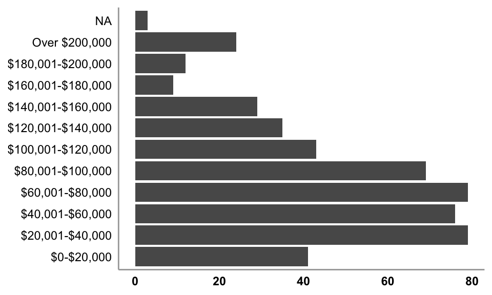

```r
df_lebe_elg %>%
  ggplot(aes(x = income)) +
  geom_bar() +
  theme(panel.grid.major = element_blank(),
        panel.grid.minor = element_blank(),
        panel.background = element_blank(),
        axis.ticks = element_blank(),
        axis.line = element_line(color = "grey66"),
        axis.text.y = element_text(color = "black"),
        axis.text.x = element_text(color = "black",
                                   face = "bold"),
        axis.title.x = element_blank(),
        axis.title.y = element_blank()) +
  coord_flip()
```

# Politics

## Ideology

Participants were asked about the extent to which they subscribe to the following ideologies on a scale of 1-7 (select NA if unfamiliar): Conservatism, Liberalism, Democratic Socialism, Libertarianism, Progressivism.

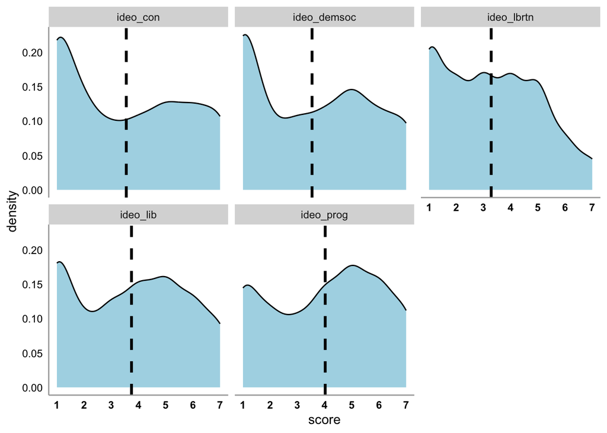

```r
means <- df_lebe_elg %>%
  dplyr::select(PID,ideo_con:ideo_prog) %>%
  pivot_longer(-PID,
               names_to = "ideo",
               values_to = "score") %>%
  filter(!is.na(score)) %>%
  group_by(ideo) %>%
  summarise(score = mean(score)) %>%
  ungroup()

df_lebe_elg %>%
  dplyr::select(PID,ideo_con:ideo_prog) %>%
  pivot_longer(-PID,
               names_to = "ideo",
               values_to = "score") %>%
  filter(!is.na(score)) %>%
  ggplot() +
  geom_density(aes(x = score), fill = "lightblue") +
  scale_x_continuous(limits = c(1,7),
                     breaks = seq(1,7,1)) +
  geom_vline(data = means,mapping = aes(xintercept = score),
             color = "black",
             linetype = "dashed",
             size = 1.1) +
  theme(panel.grid.major = element_blank(),
        panel.grid.minor = element_blank(),
        panel.background = element_blank(),
        axis.ticks = element_blank(),
        axis.line = element_line(color = "grey66"),
        axis.text.y = element_text(color = "black"),
        axis.text.x = element_text(color = "black",
                                   face = "bold")) +
  facet_wrap(~ideo,nrow = 2)
```

## Party ID

### Initial selection

```r
df_lebe_elg %>%
  group_by(party_gen) %>%
  summarise(N = n()) %>%
  ungroup() %>%
  mutate(Perc = round(100*(N/sum(N)),2)) %>%
  ungroup() %>%
  arrange(desc(N)) %>%
  kbl() %>%
  kable_styling(bootstrap_options = "hover",
                full_width = F,
                position = "left")
```

| party_gen | N | Perc |
| --- | --- | --- |
| Independent | 178 | 35.67 |
| Democrat | 160 | 32.06 |
| Republican | 155 | 31.06 |
| No preference | 6 | 1.20 |

### With followups

```r
df_lebe_elg %>%
  group_by(party_followup) %>%
  summarise(N = n()) %>%
  ungroup() %>%
  mutate(Perc = round(100*(N/sum(N)),2)) %>%
  ungroup() %>%
  kbl() %>%
  kable_styling(bootstrap_options = "hover",
                full_width = F,
                position = "left")
```

| party_followup | N | Perc |
| --- | --- | --- |
| Democrat \| Not very strong | 62 | 12.42 |
| Democrat \| Strong | 98 | 19.64 |
| Independent \| Closer to Democratic | 69 | 13.83 |
| Independent \| Closer to Republican | 49 | 9.82 |
| Independent \| Neither | 66 | 13.23 |
| Republican \| Not very strong | 67 | 13.43 |
| Republican \| Strong | 88 | 17.64 |

# Measures

## Left behind

### Continuous

People in America come from all walks of life. Some feel left behind while others are advancing. We are interested in how you feel and what that means for you.  
**To what extent do you feel left behind?** (0 = *Not at All Left Behind* to 100 = *Extremely Left Behind*)

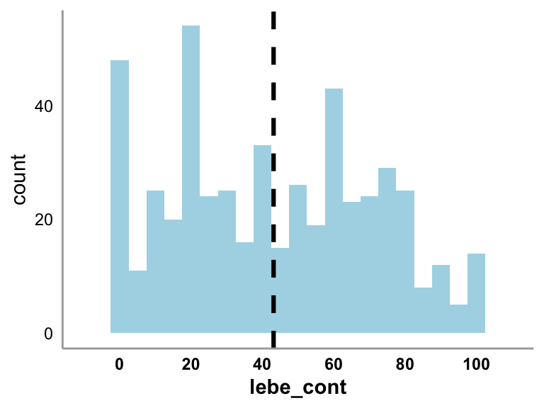

```r
df_lebe_elg %>%
  ggplot(aes(x = lebe_cont)) +
  geom_histogram(fill = "lightblue",
                 binwidth = 5) +
  scale_x_continuous(breaks = seq(0,100,20),
                     limits = c(-10,110)) +
  ylab("count") +
  geom_vline(xintercept = mean(df_lebe_elg$lebe_cont,na.rm = T),
             color = "black",
             linetype = "dashed",
             size = 1.1) +
  theme(panel.grid.major = element_blank(),
        panel.grid.minor = element_blank(),
        panel.background = element_blank(),
        axis.ticks = element_blank(),
        axis.line = element_line(color = "grey66"),
        axis.text.y = element_text(color = "black"),
        axis.text.x = element_text(color = "black",
                                   face = "bold"),
        axis.title.x = element_text(color = "black",
                                   face = "bold"))
```

### Open-ended description

IF CONTINUOUS MEASURE < 50  
Not everyone feels that they are extremely left behind, but nearly everyone can point to at least a few areas where they feel somewhat left behind…  
**In what ways, if any, do you feel left behind?**  
Please describe why you might feel left behind in as much detail as possible. There is no right or wrong answer here; just your honest thoughts about the factors that make you feel left behind.  
IF CONTINUOUS MEASURE >= 50  
**In what ways do you feel left behind?**  
Please describe why you might feel left behind in as much detail as possible. There is no right or wrong answer here; just your honest thoughts about the factors that make you feel left behind.  
*paste disabled*  
character range: 100-5000  
*Note: Adding their self-reported left-behind scores to the table below, as well as clusters (gnerated by k-means clustering the reasons’ embedding; see more on that in the text analysis section*.

| lebe_cont | cluster_label | describe |
| --- | --- | --- |
| 54 | Personal growth | Was sold a promise that to go to college, follow dreams and start a family would all be easy in America. Even though I have accomplished that, I have had to sacrifice a lot more than previous generati… |
| 12 | Lack of opportunities | I do not feel left behind at all. I have had opportunities in my life to work hard and to succeed in whatever I would like to do. My setbacks have been of my own making and mistakes I have made along … |
| 14 | Inequality and disparity | Sometimes I feel left behind in terms of wealth. We are doing well but there are people that have invested well and are very wealthy. I feel left behind by some of those people honestly. But I’m grate… |
| 0 | Inequality and disparity | I do not feel behind at all and I don’t understand why I would. I have the same opportunities as everyone else |
| 28 | Financial struggles | I was raised by a lower class family. I did not grow up with a college fund, I was never given a car by my family, wedding funds, or help with down payments for a home. I had to rely on myself to get … |
| 85 | Inequality and disparity | I feel like I am discriminated for being a man. There’s no interest that represents me out there. Even TV shows think I’m stupid and incompetent (see dumb husband commercials). Universities hate me (s… |
| 90 | Inequality and disparity | In our society there is always a hierarchy or top corporate people who are advanced and ahead while people at the bottom are at disadvantage quite often. I relate to being disadvantaged therefore I fe… |
| 10 | Inequality and disparity | I am a person of color and there’s inherent issues that come with it that make me feel out of the loop. But I’m also privileged in other ways so I’m not completely left behind |
| 62 | Financial struggles | The main reason is that I need to get a better job and build wealth for the future. Get a wife and house and children and all that, but it begins with getting a decent job. |
| 15 | Personal growth | I feel like I have gotten the things in life that I want, but I feel like it took me a lot longer to get them than it should have. So, I feel somewhat left behind even if I got to where I needed to be… |
| 64 | Personal growth | I just feel like I’m not making enough money, I’m not doing enough by not starting a family (I don’t want kids) when all of my other friends are having kids, I still struggle with money, i still want … |
| 75 | Personal growth | Because I have not achieved similar things that others in my age-range have achieved. While everyone else is having kids, getting married, buying their first house, etc. I’m just doing the same things… |
| 30 | Financial struggles | Sometimes I feel like I’m not where I should be in life. And that I am not as financially set as I should be. |
| 61 | Technology change | I sometimes feel like my peers are advancing while I am not. Given technology and how fast things are changing, I worry I may be a bit left behind. |
| 40 | Technology change | Technology is advancing so quickly that one can certainly feel left behind especially the older generations. |
| 0 | Personal growth | I don’t feel left behind at all. I work hard for what I earn and have always tried to improve my standing in the world. I don’t rely on others to “carry me forward” so I can’t be left behind. What hap… |
| 5 | Personal growth | I honestly cannot think of any way I could be left behind. I set goals and work hard to accomplish them. My life is not perfect but I’m pretty satisfied where i am and have goals to progress further. |
| 81 | Lack of opportunities | I can’t afford the latest gadgets and cars. I drive an old car and don’t have smart appliances. I feel like I’m falling behind on the modern lifestyle. |
| 59 | Career opportunities | I had never stayed on the same track as most peers when it came to furthering education and job prospects. As a result, I feel behind financially |
| 44 | Personal growth | I feel a little left behind due to the choices I have made in my life. But not to a great extent. There are others that are probably feeling this more. |
| 53 | Personal growth | I feel left behind in the career and wage earning walk of life. I just feel like I should be earning and doing more with my life. It’s pretty stressful to be honest and sometimes I just feel like i’m … |
| 60 | Financial struggles | I feel it’s very difficult to get employed, it takes so many resources just for a minimal job that doesn’t pay nearly as much as you need it to. |
| 20 | Financial struggles | I feel left behind because of the healthcare industry, specifically the ridiculous costs. Health insurance is incredibly expensive, and on top of that many times it does not even pay for what you need… |
| 25 | Technology change | I am fortunate to be where I am but everything is becoming more expensive and it doesn’t show any sign of slowing down. Combine this with the creep of technology which will automate a lot and I don’t … |
| 18 | Health limitations | I felt left behind growing up as a foster kid. I do not feel left behind now. I wasnt afforded the same oppurtunities or clothes growing up. Life is beautiful. |
| 57 | Personal growth | I feel behind because it seems like the economic situation is hard for people in the lower middle class. I also feel left behind because older generations seem to have it slightly better than I do. I … |
| 28 | Financial struggles | I feel left behind when it comes to being about to find affordable housing for my family. Rent is unrealistically high and buying a home is so complicated and expensive. |
| 46 | Personal growth | I feel a bit left behind in that I am in my mid 30s and I am still unmarried and childless. Seemingly most of my peers are married and raising young children, while I am still navigating the hellscape… |
| 75 | Social and political issues | It sometimes feels if I have been left out of a large amount of things. I feel out of place. Like I belong to a different era. The world is rapidly changing and not for the good. Too many weird ideas … |
| 40 | Inequality and disparity | I feel that the elite are taking from everyone and doing all they can to leave us behind. The current administration is leaving everyone behind they can while filling their coffers. People are becomin… |

[output cut: 469 more lines]

## Ideal candidate

We would like to ask you about your ideal political candidate.

### Experience

Thinking about experience with politics, where would your ideal candidate fall?  
1 = *Outsider* (no prior political office); 7 = *Insider* (many years in political office)

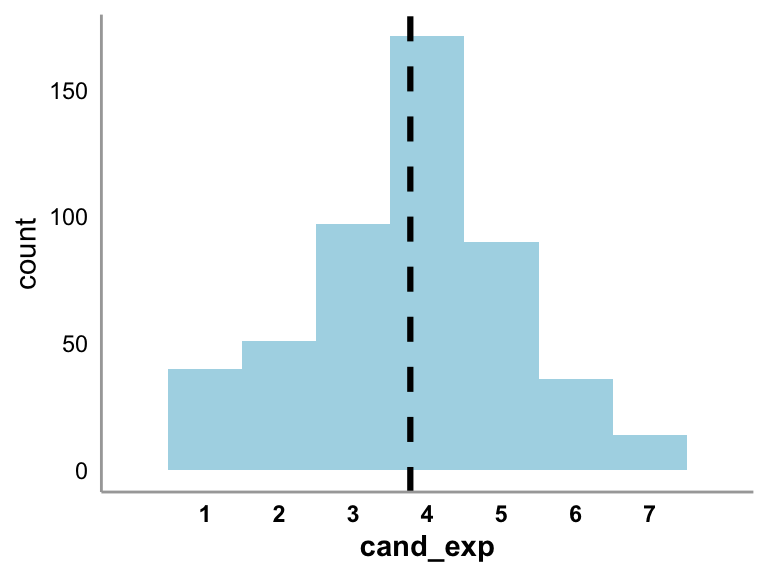

```r
df_lebe_elg %>%
  ggplot(aes(x = cand_exp)) +
  geom_histogram(fill = "lightblue",
                 binwidth = 1) +
  scale_x_continuous(breaks = seq(1,7,1),
                     limits = c(0,8)) +
  ylab("count") +
  geom_vline(xintercept = mean(df_lebe_elg$cand_exp,na.rm = T),
             color = "black",
             linetype = "dashed",
             size = 1.1) +
  theme(panel.grid.major = element_blank(),
        panel.grid.minor = element_blank(),
        panel.background = element_blank(),
        axis.ticks = element_blank(),
        axis.line = element_line(color = "grey66"),
        axis.text.y = element_text(color = "black"),
        axis.text.x = element_text(color = "black",
                                   face = "bold"),
        axis.title.x = element_text(color = "black",
                                   face = "bold"))
```

### Change

**Reverse-scored:**  
Thinking about how they would approach change, what approach would you like them to take?  
1 = *Sweeping* (bold, radical changes); 7 = *Incremental* (smaller, step-by-step changes)

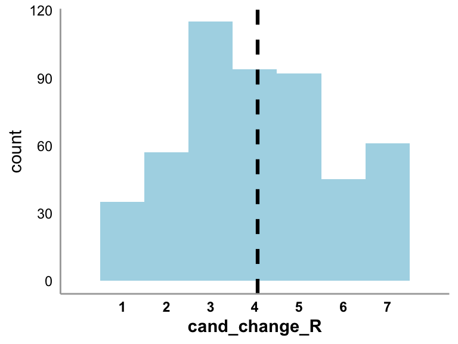

```r
df_lebe_elg %>%
  ggplot(aes(x = cand_change_R)) +
  geom_histogram(fill = "lightblue",
                 binwidth = 1) +
  scale_x_continuous(breaks = seq(1,7,1),
                     limits = c(0,8)) +
  ylab("count") +
  geom_vline(xintercept = mean(df_lebe_elg$cand_change_R,na.rm = T),
             color = "black",
             linetype = "dashed",
             size = 1.1) +
  theme(panel.grid.major = element_blank(),
        panel.grid.minor = element_blank(),
        panel.background = element_blank(),
        axis.ticks = element_blank(),
        axis.line = element_line(color = "grey66"),
        axis.text.y = element_text(color = "black"),
        axis.text.x = element_text(color = "black",
                                   face = "bold"),
        axis.title.x = element_text(color = "black",
                                   face = "bold"))
```

### Left-Right ideology

Mean score of economic policy (1 = *Redistributive* to 7 = *Free Market*) and cultural issues (1 = *Progressive* to 7 = *Conservative*).

r = 0.66

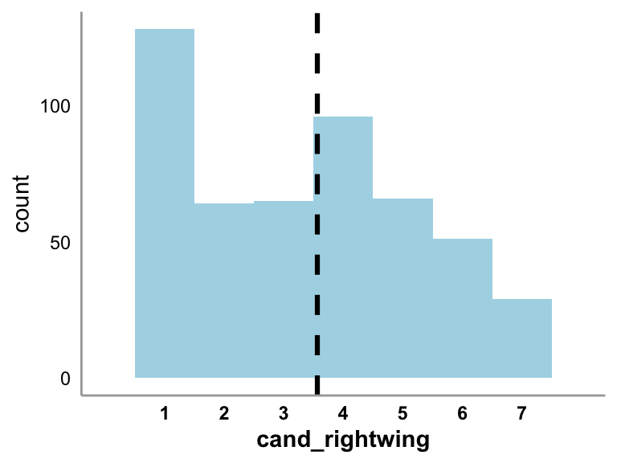

```r
df_lebe_elg %>%
  ggplot(aes(x = cand_rightwing)) +
  geom_histogram(fill = "lightblue",
                 binwidth = 1) +
  scale_x_continuous(breaks = seq(1,7,1),
                     limits = c(0,8)) +
  ylab("count") +
  geom_vline(xintercept = mean(df_lebe_elg$cand_rightwing,na.rm = T),
             color = "black",
             linetype = "dashed",
             size = 1.1) +
  theme(panel.grid.major = element_blank(),
        panel.grid.minor = element_blank(),
        panel.background = element_blank(),
        axis.ticks = element_blank(),
        axis.line = element_line(color = "grey66"),
        axis.text.y = element_text(color = "black"),
        axis.text.x = element_text(color = "black",
                                   face = "bold"),
        axis.title.x = element_text(color = "black",
                                   face = "bold"))
```

## Text analysis

I looped through their open-ended responses with gpt-4o to get the following: (1) left behind score; (2) reasons; (3) systemic; (4) government-related; (5) economic; (6) cultural; (7) race-related; (8) gender-related; (9) age-related.

### Left behind score

To what extent is this person feeling left behind?

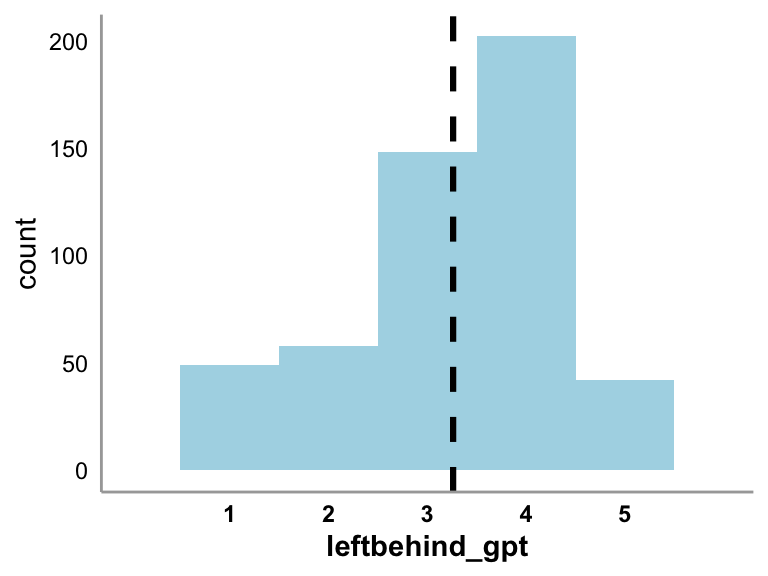

```r
df_lebe_elg %>%
  ggplot(aes(x = leftbehind_gpt)) +
  geom_histogram(fill = "lightblue",
                 binwidth = 1) +
  scale_x_continuous(breaks = seq(1,5,1),
                     limits = c(0,6)) +
  ylab("count") +
  geom_vline(xintercept = mean(df_lebe_elg$leftbehind_gpt,na.rm = T),
             color = "black",
             linetype = "dashed",
             size = 1.1) +
  theme(panel.grid.major = element_blank(),
        panel.grid.minor = element_blank(),
        panel.background = element_blank(),
        axis.ticks = element_blank(),
        axis.line = element_line(color = "grey66"),
        axis.text.y = element_text(color = "black"),
        axis.text.x = element_text(color = "black",
                                   face = "bold"),
        axis.title.x = element_text(color = "black",
                                   face = "bold"))
```

### Reasons

What are the factors that are making this person feel left behind?

```r
df_lebe_elg %>%
  select(reasons) %>%
  kbl() %>%
  kable_styling(bootstrap_options = "hover",
                position = "left") %>%
  scroll_box(width = "100%", height = "400px")
```

| reasons |
| --- |
| unfulfilled promises, high expectations, sacrifices made, generational differences, work-life balance |
| personal setbacks, self-made mistakes |
| wealth disparity, investment success |
| equal opportunities |
| financial support, education access, family resources, economic background, self-reliance |
| gender discrimination, media portrayal, lack of representation, educational bias |
| economic disparity, career stagnation, social inequality |
| racial bias, privilege awareness |
| job prospects, wealth building, family planning, housing stability |
| delayed progress, time management, personal expectations |
| financial struggles, family expectations, peer pressure, personal choices |
| life milestones, career stagnation, financial stability, relationship status |
| financial insecurity, career stagnation |
| technology changes, peer advancement |
| technology advancement, age gap, digital skills, rapid change |
| self-reliance, personal responsibility, hard work, self-improvement |
| goal setting, hard work, satisfaction, progress goals |
| financial constraints, outdated technology, old car, lack of smart appliances, modern lifestyle gap |
| education gap, career stagnation, financial instability |
| life choices |
| career stagnation, wage disparity, goal progress, stress, self-expectations |
| employment difficulty, low wages, resource scarcity |
| healthcare costs, insurance expenses, policy influence, lobbying power |
| rising costs, technology creep, job automation, economic uncertainty |
| foster care, limited opportunities, lack of resources |
| economic situation, lower middle class, older generations, life progress, unmet expectations |
| housing costs, high rent, home buying complexity |
| relationship status, peer comparison, family expectations, social pressure |
| rapid change, cultural shifts, feeling outdated, social pressure |
| economic inequality, political corruption, social division, wealth disparity, government neglect |

[output cut: 469 more lines]

### Systemic

Would you say that the factors that make this person feel left behind are more systemic (larger forces outside their control, like government, society, culture, or the economy) or more individual (their own circumstances and choice)? (1 = *entirely individual* to 7 = *entirely systemic*)

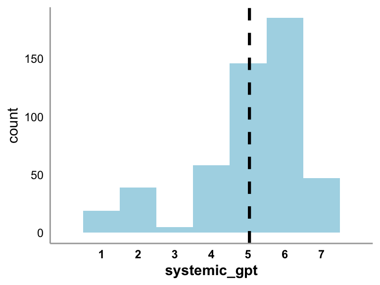

```r
df_lebe_elg %>%
  ggplot(aes(x = systemic_gpt)) +
  geom_histogram(fill = "lightblue",
                 binwidth = 1) +
  scale_x_continuous(breaks = seq(1,7,1),
                     limits = c(0,8)) +
  ylab("count") +
  geom_vline(xintercept = mean(df_lebe_elg$systemic_gpt,na.rm = T),
             color = "black",
             linetype = "dashed",
             size = 1.1) +
  theme(panel.grid.major = element_blank(),
        panel.grid.minor = element_blank(),
        panel.background = element_blank(),
        axis.ticks = element_blank(),
        axis.line = element_line(color = "grey66"),
        axis.text.y = element_text(color = "black"),
        axis.text.x = element_text(color = "black",
                                   face = "bold"),
        axis.title.x = element_text(color = "black",
                                   face = "bold"))
```

### Government-related

To what extent are the factors related to the government?

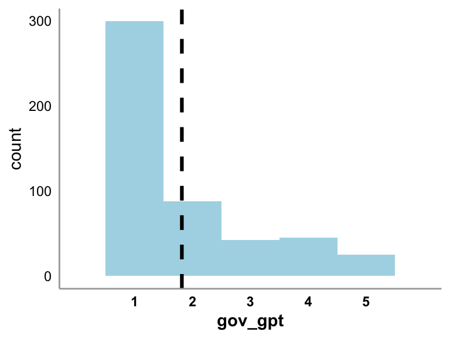

```r
df_lebe_elg %>%
  ggplot(aes(x = gov_gpt)) +
  geom_histogram(fill = "lightblue",
                 binwidth = 1) +
  scale_x_continuous(breaks = seq(1,5,1),
                     limits = c(0,6)) +
  ylab("count") +
  geom_vline(xintercept = mean(df_lebe_elg$gov_gpt,na.rm = T),
             color = "black",
             linetype = "dashed",
             size = 1.1) +
  theme(panel.grid.major = element_blank(),
        panel.grid.minor = element_blank(),
        panel.background = element_blank(),
        axis.ticks = element_blank(),
        axis.line = element_line(color = "grey66"),
        axis.text.y = element_text(color = "black"),
        axis.text.x = element_text(color = "black",
                                   face = "bold"),
        axis.title.x = element_text(color = "black",
                                   face = "bold"))
```

### Economic

To what extent are the factors related to economic conditions?

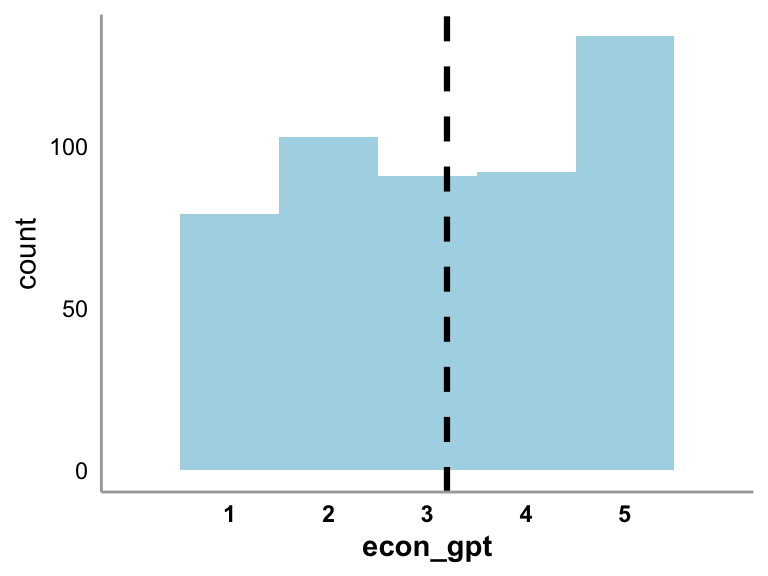

```r
df_lebe_elg %>%
  ggplot(aes(x = econ_gpt)) +
  geom_histogram(fill = "lightblue",
                 binwidth = 1) +
  scale_x_continuous(breaks = seq(1,5,1),
                     limits = c(0,6)) +
  ylab("count") +
  geom_vline(xintercept = mean(df_lebe_elg$econ_gpt,na.rm = T),
             color = "black",
             linetype = "dashed",
             size = 1.1) +
  theme(panel.grid.major = element_blank(),
        panel.grid.minor = element_blank(),
        panel.background = element_blank(),
        axis.ticks = element_blank(),
        axis.line = element_line(color = "grey66"),
        axis.text.y = element_text(color = "black"),
        axis.text.x = element_text(color = "black",
                                   face = "bold"),
        axis.title.x = element_text(color = "black",
                                   face = "bold"))
```

### Cultural

To what extent are the factors related to cultural issues (like dignity, feeling respected, feeling valued)?

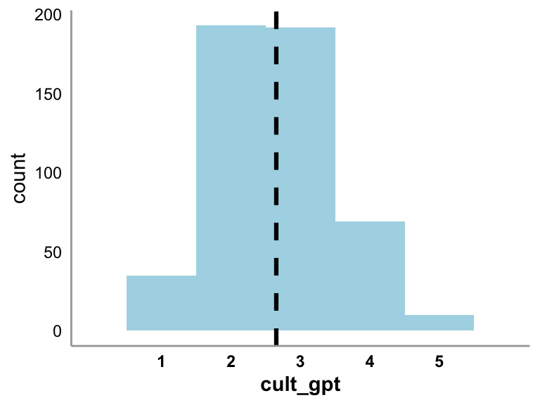

```r
df_lebe_elg %>%
  ggplot(aes(x = cult_gpt)) +
  geom_histogram(fill = "lightblue",
                 binwidth = 1) +
  scale_x_continuous(breaks = seq(1,5,1),
                     limits = c(0,6)) +
  ylab("count") +
  geom_vline(xintercept = mean(df_lebe_elg$cult_gpt,na.rm = T),
             color = "black",
             linetype = "dashed",
             size = 1.1) +
  theme(panel.grid.major = element_blank(),
        panel.grid.minor = element_blank(),
        panel.background = element_blank(),
        axis.ticks = element_blank(),
        axis.line = element_line(color = "grey66"),
        axis.text.y = element_text(color = "black"),
        axis.text.x = element_text(color = "black",
                                   face = "bold"),
        axis.title.x = element_text(color = "black",
                                   face = "bold"))
```

### Race

To what extent are the factors related to racial background?

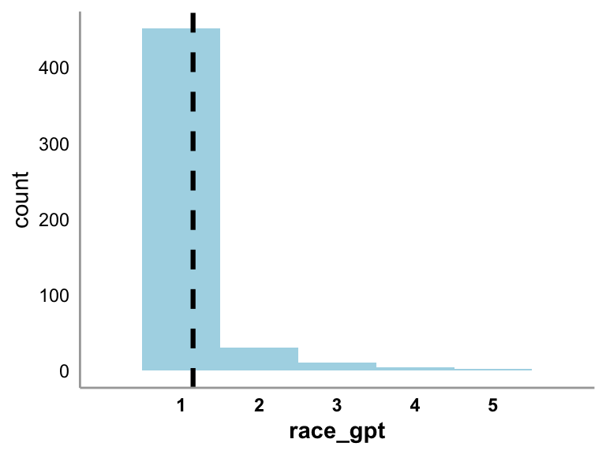

```r
df_lebe_elg %>%
  ggplot(aes(x = race_gpt)) +
  geom_histogram(fill = "lightblue",
                 binwidth = 1) +
  scale_x_continuous(breaks = seq(1,5,1),
                     limits = c(0,6)) +
  ylab("count") +
  geom_vline(xintercept = mean(df_lebe_elg$race_gpt,na.rm = T),
             color = "black",
             linetype = "dashed",
             size = 1.1) +
  theme(panel.grid.major = element_blank(),
        panel.grid.minor = element_blank(),
        panel.background = element_blank(),
        axis.ticks = element_blank(),
        axis.line = element_line(color = "grey66"),
        axis.text.y = element_text(color = "black"),
        axis.text.x = element_text(color = "black",
                                   face = "bold"),
        axis.title.x = element_text(color = "black",
                                   face = "bold"))
```

### Gender

To what extent are the factors related to gender?

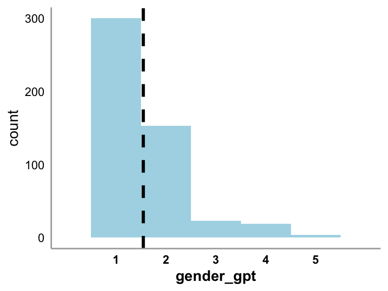

```r
df_lebe_elg %>%
  ggplot(aes(x = gender_gpt)) +
  geom_histogram(fill = "lightblue",
                 binwidth = 1) +
  scale_x_continuous(breaks = seq(1,5,1),
                     limits = c(0,6)) +
  ylab("count") +
  geom_vline(xintercept = mean(df_lebe_elg$gender_gpt,na.rm = T),
             color = "black",
             linetype = "dashed",
             size = 1.1) +
  theme(panel.grid.major = element_blank(),
        panel.grid.minor = element_blank(),
        panel.background = element_blank(),
        axis.ticks = element_blank(),
        axis.line = element_line(color = "grey66"),
        axis.text.y = element_text(color = "black"),
        axis.text.x = element_text(color = "black",
                                   face = "bold"),
        axis.title.x = element_text(color = "black",
                                   face = "bold"))
```

### Age

To what extent are the factors related to age?

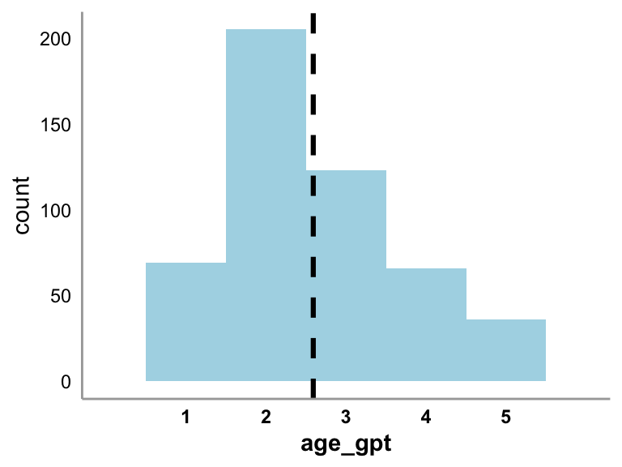

```r
df_lebe_elg %>%
  ggplot(aes(x = age_gpt)) +
  geom_histogram(fill = "lightblue",
                 binwidth = 1) +
  scale_x_continuous(breaks = seq(1,5,1),
                     limits = c(0,6)) +
  ylab("count") +
  geom_vline(xintercept = mean(df_lebe_elg$age_gpt,na.rm = T),
             color = "black",
             linetype = "dashed",
             size = 1.1) +
  theme(panel.grid.major = element_blank(),
        panel.grid.minor = element_blank(),
        panel.background = element_blank(),
        axis.ticks = element_blank(),
        axis.line = element_line(color = "grey66"),
        axis.text.y = element_text(color = "black"),
        axis.text.x = element_text(color = "black",
                                   face = "bold"),
        axis.title.x = element_text(color = "black",
                                   face = "bold"))
```

## Cluster analysis

I took the embeddings of the gpt-generated reasons and clustered them using k-means clustering. These are the top-five reasons in each cluster. The label was generated by chat-gpt.

```r
top_examples %>%
  left_join(df_lebe_elg %>%
              select(cluster,cluster_label) %>%
              distinct(),by = "cluster") %>%
  select(-cluster) %>%
  select(cluster_label,reason,cosine_to_centroid) %>%
  kbl() %>%
  kable_styling(bootstrap_options = "hover",
                position = "left") %>%
  scroll_box(width = "100%", height = "400px")
```

| cluster_label | reason | cosine_to_centroid |
| --- | --- | --- |
| Family responsibilities | family responsibilities | 0.7598607 |
| Family responsibilities | family dynamics | 0.7465555 |
| Family responsibilities | family obligations | 0.7373948 |
| Family responsibilities | family reliance | 0.7142502 |
| Family responsibilities | family support | 0.7043477 |
| Personal growth | personal progress | 0.7195920 |
| Personal growth | personal expectations | 0.6988246 |
| Personal growth | personal growth | 0.6923641 |
| Personal growth | life goals | 0.6644831 |
| Personal growth | personal development | 0.6635700 |
| Career opportunities | career opportunities | 0.7595985 |
| Career opportunities | employment opportunities | 0.7542357 |
| Career opportunities | career growth | 0.7541738 |
| Career opportunities | job opportunities | 0.7532120 |
| Career opportunities | career success | 0.7516520 |
| Inequality and disparity | economic disparity | 0.8400239 |
| Inequality and disparity | income disparity | 0.8367864 |
| Inequality and disparity | economic inequality | 0.8299088 |
| Inequality and disparity | racial inequality | 0.8207277 |
| Inequality and disparity | social inequality | 0.8074090 |
| Health limitations | health limitations | 0.7376653 |
| Health limitations | activity limitations | 0.7034713 |
| Health limitations | health issues | 0.6868075 |
| Health limitations | disability challenges | 0.6849473 |
| Health limitations | physical challenges | 0.6762576 |
| Technology change | technology advances | 0.7843034 |
| Technology change | technology advancement | 0.7702799 |
| Technology change | tech adaptation | 0.7580332 |
| Technology change | technology advancements | 0.7575246 |
| Technology change | technology changes | 0.7524106 |
| Financial struggles | financial struggles | 0.7629190 |
| Financial struggles | financial concerns | 0.7521540 |
| Financial struggles | financial struggle | 0.7366108 |
| Financial struggles | financial situation | 0.7293220 |
| Financial struggles | limited income | 0.7202934 |
| Lack of opportunities | lack of fulfillment | 0.7177588 |
| Lack of opportunities | lack of advancement | 0.7158078 |
| Lack of opportunities | lack of opportunities | 0.7148162 |
| Lack of opportunities | lack of progress | 0.7066329 |
| Lack of opportunities | lack of support | 0.7023977 |
| Social and political issues | social issues | 0.7032514 |
| Social and political issues | social changes | 0.7010637 |
| Social and political issues | political issues | 0.6975369 |
| Social and political issues | political shifts | 0.6831680 |
| Social and political issues | policy shifts | 0.6788993 |
| Generational differences | generation gap | 0.7899701 |
| Generational differences | age differences | 0.7837976 |
| Generational differences | age gap | 0.7809158 |
| Generational differences | generational gap | 0.7702265 |
| Generational differences | education gaps | 0.7510724 |

```r
df_lebe_elg %>%
  group_by(cluster_label) %>%
  summarise(N = n(),
            M_leftbehind = mean(lebe_cont,na.rm = T)) %>%
  ungroup() %>%
  mutate(Perc = round(100*(N/sum(N)),2)) %>%
  ungroup() %>%
  select(cluster_label,N,Perc,M_leftbehind) %>%
  arrange(desc(N)) %>%
  kbl() %>%
  kable_styling(bootstrap_options = "hover",
                full_width = F,
                position = "left")
```

| cluster_label | N | Perc | M_leftbehind |
| --- | --- | --- | --- |
| Financial struggles | 114 | 22.85 | 46.56140 |
| Lack of opportunities | 86 | 17.23 | 48.24419 |
| Personal growth | 76 | 15.23 | 34.32895 |
| Health limitations | 55 | 11.02 | 45.52727 |
| Social and political issues | 43 | 8.62 | 50.06977 |
| Inequality and disparity | 38 | 7.62 | 50.57895 |
| Career opportunities | 35 | 7.01 | 43.97143 |
| Generational differences | 19 | 3.81 | 24.47368 |
| Technology change | 19 | 3.81 | 27.31579 |
| Family responsibilities | 14 | 2.81 | 25.28571 |

# Analysis

## Correlations

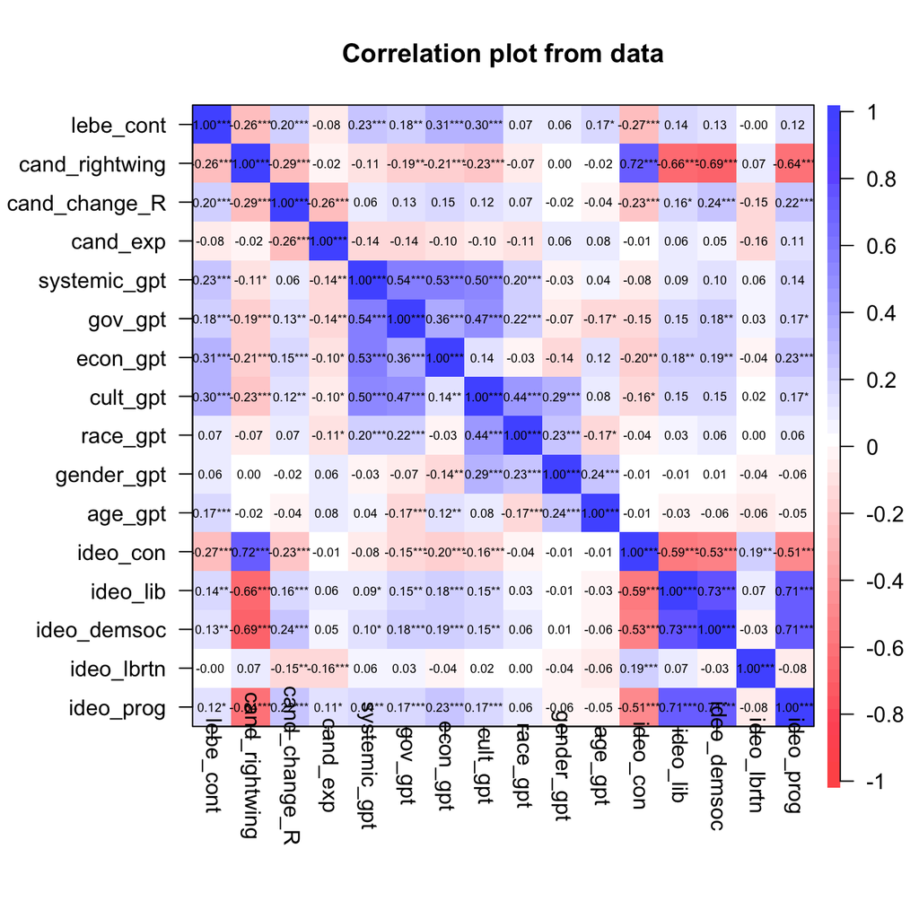

## Preregistered analyses

### DV: Candidate support for sweeping change

Just as a reminder, this is the measure for this DV…  
**Reverse-scored:** Thinking about how they would approach change, what approach would you like them to take? 1 = *Sweeping* (bold, radical changes); 7 = *Incremental* (smaller, step-by-step changes)

#### Model 1A

**Outcome:** Sweeping change candidate  
**Predictor:** left behind - continuous

```r
m1 <- lm(cand_change_R ~ lebe_cont,data = df_lebe_elg)

apa_lm <- apa_print(m1)

kbl(apa_lm$table) %>%
  kable_styling(bootstrap_options = "hover",
                full_width = F,
                position = "left")
```

| term | estimate | conf.int | statistic | df | p.value |
| --- | --- | --- | --- | --- | --- |
| Intercept | 3.55 | [3.28, 3.82] | 25.73 | 497 | < .001 |
| Lebe cont | 0.01 | [0.01, 0.02] | 4.45 | 497 | < .001 |

#### Model 1B

**Outcome:** Sweeping change candidate  
**Predictor:** left behind - continuous  
**Controls:** race (white = 1; non-white = 0), gender (man = 1; non-man = 0), income (numeric), education (numeric), age

```r
m1 <- lm(cand_change_R ~ lebe_cont + white_bin + man_bin + income_num + edu_num + age,data = df_lebe_elg)

apa_lm <- apa_print(m1)

kbl(apa_lm$table) %>%
  kable_styling(bootstrap_options = "hover",
                full_width = F,
                position = "left")
```

| term | estimate | conf.int | statistic | df | p.value |
| --- | --- | --- | --- | --- | --- |
| Intercept | 4.41 | [3.52, 5.29] | 9.77 | 481 | < .001 |
| Lebe cont | 0.01 | [0.00, 0.02] | 3.15 | 481 | .002 |
| White bin | 0.19 | [-0.17, 0.55] | 1.05 | 481 | .293 |
| Man bin | 0.12 | [-0.19, 0.42] | 0.77 | 481 | .444 |
| Income num | -0.05 | [-0.11, 0.02] | -1.36 | 481 | .174 |
| Edu num | -0.08 | [-0.22, 0.06] | -1.13 | 481 | .260 |
| Age | -0.01 | [-0.02, 0.00] | -1.74 | 481 | .082 |

#### Model 1C

**Outcome:** Sweeping change candidate  
**Predictor:** left behind - continuous  
**Controls:** party id, conservative ideology, progressive ideology, race (white = 1; non-white = 0), gender (man = 1; non-man = 0), income (numeric), education (numeric), age

```r
m1 <- lm(cand_change_R ~ lebe_cont + party_gen + ideo_con + ideo_prog + white_bin + man_bin + income_num + edu_num + age,data = df_lebe_elg)

apa_lm <- apa_print(m1)

kbl(apa_lm$table) %>%
  kable_styling(bootstrap_options = "hover",
                full_width = F,
                position = "left")
```

| term | estimate | conf.int | statistic | df | p.value |
| --- | --- | --- | --- | --- | --- |
| Intercept | 4.72 | [3.61, 5.84] | 8.34 | 443 | < .001 |
| Lebe cont | 0.01 | [0.00, 0.01] | 2.13 | 443 | .034 |
| Party genIndependent | -0.16 | [-0.56, 0.24] | -0.77 | 443 | .444 |
| Party genNo preference | -0.05 | [-1.43, 1.33] | -0.07 | 443 | .942 |
| Party genRepublican | -0.33 | [-0.86, 0.21] | -1.20 | 443 | .231 |
| Ideo con | -0.08 | [-0.18, 0.02] | -1.56 | 443 | .119 |
| Ideo prog | 0.09 | [0.00, 0.19] | 2.00 | 443 | .046 |
| White bin | 0.24 | [-0.13, 0.62] | 1.29 | 443 | .199 |
| Man bin | 0.10 | [-0.21, 0.41] | 0.65 | 443 | .514 |
| Income num | -0.07 | [-0.14, -0.01] | -2.14 | 443 | .033 |
| Edu num | -0.11 | [-0.25, 0.03] | -1.54 | 443 | .125 |
| Age | -0.01 | [-0.02, 0.00] | -1.31 | 443 | .192 |

### DV: Right-wing candidate

#### Model 2A

**Outcome:** Right-wing candidate  
**Predictor:** left behind - continuous

```r
m1 <- lm(cand_rightwing ~ lebe_cont,data = df_lebe_elg)

apa_lm <- apa_print(m1)

kbl(apa_lm$table) %>%
  kable_styling(bootstrap_options = "hover",
                full_width = F,
                position = "left")
```

| term | estimate | conf.int | statistic | df | p.value |
| --- | --- | --- | --- | --- | --- |
| Intercept | 4.32 | [4.03, 4.62] | 28.68 | 497 | < .001 |
| Lebe cont | -0.02 | [-0.02, -0.01] | -6.04 | 497 | < .001 |

#### Model 2B

**Outcome:** Right-wing candidate  
**Predictor:** left behind - continuous  
**Controls:** race (white = 1; non-white = 0), gender (man = 1; non-man = 0), income (numeric), education (numeric), age

```r
m1 <- lm(cand_rightwing ~ lebe_cont + white_bin + man_bin + income_num + edu_num + age,data = df_lebe_elg)

apa_lm <- apa_print(m1)

kbl(apa_lm$table) %>%
  kable_styling(bootstrap_options = "hover",
                full_width = F,
                position = "left")
```

| term | estimate | conf.int | statistic | df | p.value |
| --- | --- | --- | --- | --- | --- |
| Intercept | 4.08 | [3.12, 5.05] | 8.32 | 481 | < .001 |
| Lebe cont | -0.02 | [-0.02, -0.01] | -5.60 | 481 | < .001 |
| White bin | 0.00 | [-0.39, 0.38] | -0.02 | 481 | .981 |
| Man bin | 0.33 | [0.00, 0.66] | 1.94 | 481 | .053 |
| Income num | 0.01 | [-0.06, 0.08] | 0.31 | 481 | .754 |
| Edu num | -0.11 | [-0.25, 0.04] | -1.40 | 481 | .163 |
| Age | 0.01 | [0.00, 0.02] | 1.49 | 481 | .137 |

#### Model 2C

**Outcome:** Right-wing candidate  
**Predictor:** left behind - continuous  
**Controls:** party id, conservative ideology, progressive ideology, race (white = 1; non-white = 0), gender (man = 1; non-man = 0), income (numeric), education (numeric), age

```r
m1 <- lm(cand_rightwing ~ lebe_cont + party_gen + ideo_con + ideo_prog + white_bin + man_bin + income_num + edu_num + age,data = df_lebe_elg)

apa_lm <- apa_print(m1)

kbl(apa_lm$table) %>%
  kable_styling(bootstrap_options = "hover",
                full_width = F,
                position = "left")
```

| term | estimate | conf.int | statistic | df | p.value |
| --- | --- | --- | --- | --- | --- |
| Intercept | 2.77 | [2.02, 3.51] | 7.31 | 443 | < .001 |
| Lebe cont | 0.00 | [-0.01, 0.00] | -2.31 | 443 | .021 |
| Party genIndependent | 0.68 | [0.42, 0.95] | 5.02 | 443 | < .001 |
| Party genNo preference | 0.61 | [-0.31, 1.53] | 1.30 | 443 | .196 |
| Party genRepublican | 1.53 | [1.17, 1.89] | 8.41 | 443 | < .001 |
| Ideo con | 0.29 | [0.22, 0.36] | 8.29 | 443 | < .001 |
| Ideo prog | -0.29 | [-0.35, -0.23] | -9.29 | 443 | < .001 |
| White bin | -0.10 | [-0.35, 0.15] | -0.80 | 443 | .425 |
| Man bin | 0.18 | [-0.02, 0.39] | 1.74 | 443 | .082 |
| Income num | 0.03 | [-0.01, 0.08] | 1.55 | 443 | .121 |
| Edu num | 0.01 | [-0.09, 0.10] | 0.12 | 443 | .907 |
| Age | 0.01 | [0.00, 0.01] | 1.28 | 443 | .200 |

## Exploratory analyses

### DV: Candidate support for sweeping change

Just as a reminder, this is the measure for this DV…  
**Reverse-scored:** Thinking about how they would approach change, what approach would you like them to take? 1 = *Sweeping* (bold, radical changes); 7 = *Incremental* (smaller, step-by-step changes)

#### By Cluster

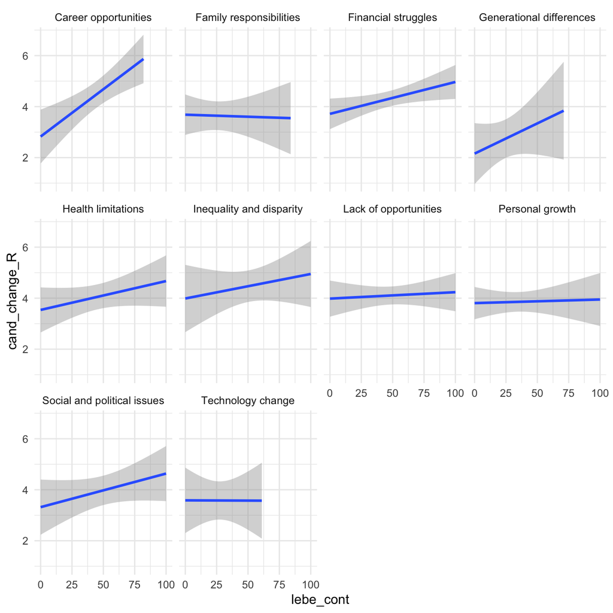

#### Moderator: Systemic vs. individual factors

**Outcome:** Sweeping change candidate  
**Predictor:** left behind - continuous

```r
m1 <- lm(cand_change_R ~ lebe_cont*systemic_gpt,data = df_lebe_elg)

apa_lm <- apa_print(m1)

kbl(apa_lm$table) %>%
  kable_styling(bootstrap_options = "hover",
                full_width = F,
                position = "left")
```

| term | estimate | conf.int | statistic | df | p.value |
| --- | --- | --- | --- | --- | --- |
| Intercept | 3.91 | [3.10, 4.71] | 9.58 | 495 | < .001 |
| Lebe cont | 0.00 | [-0.02, 0.02] | -0.14 | 495 | .890 |
| Systemic gpt | -0.07 | [-0.23, 0.09] | -0.89 | 495 | .372 |
| Lebe cont $\times$ Systemic gpt | 0.00 | [0.00, 0.01] | 1.46 | 495 | .145 |

#### Moderator: Government-related

**Outcome:** Sweeping change candidate  
**Predictor:** left behind - continuous

```r
m1 <- lm(cand_change_R ~ lebe_cont*gov_gpt,data = df_lebe_elg)

apa_lm <- apa_print(m1)

kbl(apa_lm$table) %>%
  kable_styling(bootstrap_options = "hover",
                full_width = F,
                position = "left")
```

| term | estimate | conf.int | statistic | df | p.value |
| --- | --- | --- | --- | --- | --- |
| Intercept | 3.70 | [3.22, 4.19] | 15.06 | 495 | < .001 |
| Lebe cont | 0.00 | [-0.01, 0.01] | 0.62 | 495 | .533 |
| Gov gpt | -0.07 | [-0.32, 0.17] | -0.59 | 495 | .552 |
| Lebe cont $\times$ Gov gpt | 0.00 | [0.00, 0.01] | 1.95 | 495 | .051 |

#### Moderator: Economic conditions

**Outcome:** Sweeping change candidate  
**Predictor:** left behind - continuous

```r
m1 <- lm(cand_change_R ~ lebe_cont*econ_gpt,data = df_lebe_elg)

apa_lm <- apa_print(m1)

kbl(apa_lm$table) %>%
  kable_styling(bootstrap_options = "hover",
                full_width = F,
                position = "left")
```

| term | estimate | conf.int | statistic | df | p.value |
| --- | --- | --- | --- | --- | --- |
| Intercept | 3.57 | [2.99, 4.16] | 12.00 | 495 | < .001 |
| Lebe cont | 0.00 | [-0.01, 0.01] | 0.22 | 495 | .824 |
| Econ gpt | 0.01 | [-0.18, 0.19] | 0.06 | 495 | .952 |
| Lebe cont $\times$ Econ gpt | 0.00 | [0.00, 0.01] | 1.41 | 495 | .158 |

#### Moderator: Cultural issues

**Outcome:** Sweeping change candidate  
**Predictor:** left behind - continuous

```r
m1 <- lm(cand_change_R ~ lebe_cont*cult_gpt,data = df_lebe_elg)

apa_lm <- apa_print(m1)

kbl(apa_lm$table) %>%
  kable_styling(bootstrap_options = "hover",
                full_width = F,
                position = "left")
```

| term | estimate | conf.int | statistic | df | p.value |
| --- | --- | --- | --- | --- | --- |
| Intercept | 3.93 | [3.14, 4.71] | 9.84 | 495 | < .001 |
| Lebe cont | -0.01 | [-0.02, 0.01] | -0.83 | 495 | .405 |
| Cult gpt | -0.14 | [-0.45, 0.17] | -0.91 | 495 | .364 |
| Lebe cont $\times$ Cult gpt | 0.01 | [0.00, 0.01] | 2.24 | 495 | .026 |

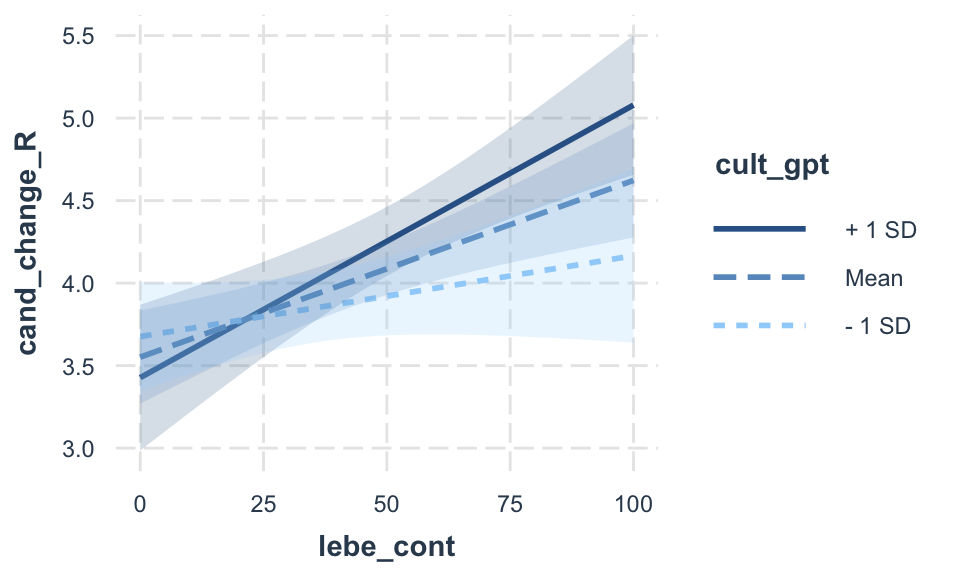

```r
interact_plot(m1,
              pred = "lebe_cont",
              modx = "cult_gpt",
              interval = T)
```

#### Moderator: Racial background

**Outcome:** Sweeping change candidate  
**Predictor:** left behind - continuous

```r
m1 <- lm(cand_change_R ~ lebe_cont*race_gpt,data = df_lebe_elg)

apa_lm <- apa_print(m1)

kbl(apa_lm$table) %>%
  kable_styling(bootstrap_options = "hover",
                full_width = F,
                position = "left")
```

| term | estimate | conf.int | statistic | df | p.value |
| --- | --- | --- | --- | --- | --- |
| Intercept | 4.43 | [3.60, 5.25] | 10.53 | 495 | < .001 |
| Lebe cont | -0.01 | [-0.03, 0.01] | -1.30 | 495 | .196 |
| Race gpt | -0.80 | [-1.52, -0.09] | -2.21 | 495 | .028 |
| Lebe cont $\times$ Race gpt | 0.02 | [0.01, 0.03] | 2.98 | 495 | .003 |

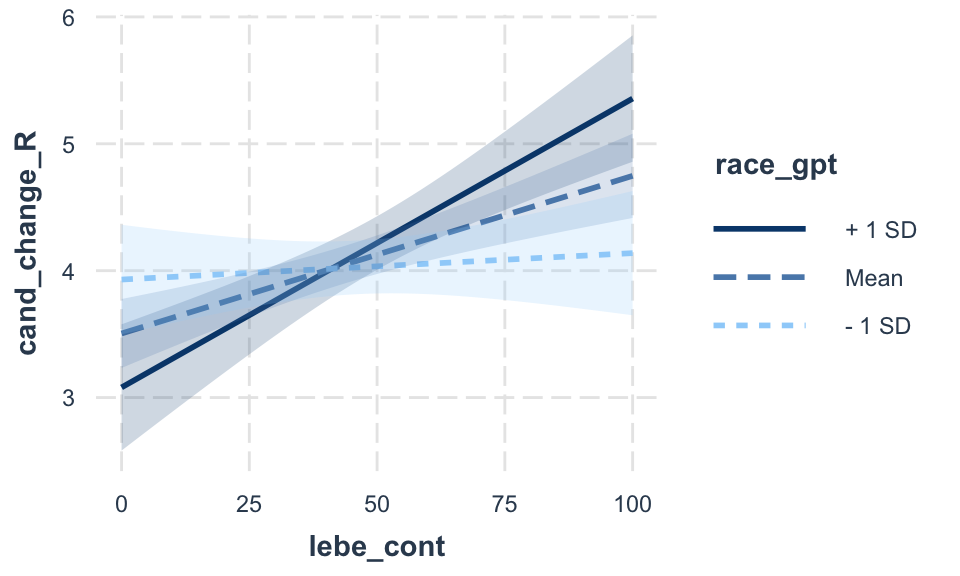

```r
interact_plot(m1,
              pred = "lebe_cont",
              modx = "race_gpt",
              interval = T)
```

#### Moderator: Gender

**Outcome:** Sweeping change candidate  
**Predictor:** left behind - continuous

```r
m1 <- lm(cand_change_R ~ lebe_cont*gender_gpt,data = df_lebe_elg)

apa_lm <- apa_print(m1)

kbl(apa_lm$table) %>%
  kable_styling(bootstrap_options = "hover",
                full_width = F,
                position = "left")
```

| term | estimate | conf.int | statistic | df | p.value |
| --- | --- | --- | --- | --- | --- |
| Intercept | 3.87 | [3.30, 4.44] | 13.32 | 495 | < .001 |
| Lebe cont | 0.01 | [0.00, 0.02] | 1.20 | 495 | .231 |
| Gender gpt | -0.22 | [-0.56, 0.12] | -1.25 | 495 | .212 |
| Lebe cont $\times$ Gender gpt | 0.00 | [0.00, 0.01] | 1.06 | 495 | .290 |

#### Moderator: Age

**Outcome:** Sweeping change candidate  
**Predictor:** left behind - continuous

```r
m1 <- lm(cand_change_R ~ lebe_cont*age_gpt,data = df_lebe_elg)

apa_lm <- apa_print(m1)

kbl(apa_lm$table) %>%
  kable_styling(bootstrap_options = "hover",
                full_width = F,
                position = "left")
```

| term | estimate | conf.int | statistic | df | p.value |
| --- | --- | --- | --- | --- | --- |
| Intercept | 3.81 | [3.19, 4.43] | 12.10 | 495 | < .001 |
| Lebe cont | 0.01 | [0.00, 0.03] | 2.05 | 495 | .041 |
| Age gpt | -0.12 | [-0.35, 0.12] | -0.96 | 495 | .336 |
| Lebe cont $\times$ Age gpt | 0.00 | [0.00, 0.00] | -0.06 | 495 | .949 |

### DV: Right-wing candidate

#### By Cluster

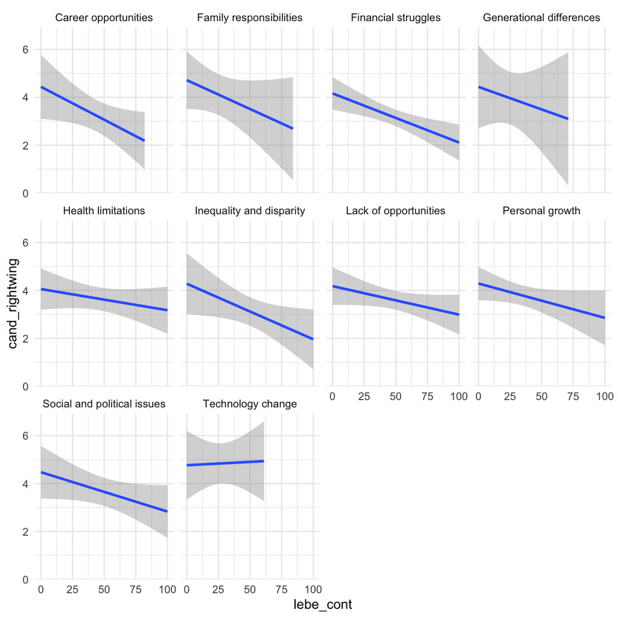

#### Moderator: Systemic vs. individual factors

**Outcome:** Right-wing candidate  
**Predictor:** left behind - continuous

```r
m1 <- lm(cand_rightwing ~ lebe_cont*systemic_gpt,data = df_lebe_elg)

apa_lm <- apa_print(m1)

kbl(apa_lm$table) %>%
  kable_styling(bootstrap_options = "hover",
                full_width = F,
                position = "left")
```

| term | estimate | conf.int | statistic | df | p.value |
| --- | --- | --- | --- | --- | --- |
| Intercept | 4.24 | [3.36, 5.11] | 9.52 | 495 | < .001 |
| Lebe cont | 0.00 | [-0.02, 0.02] | -0.43 | 495 | .670 |
| Systemic gpt | 0.01 | [-0.16, 0.19] | 0.15 | 495 | .879 |
| Lebe cont $\times$ Systemic gpt | 0.00 | [-0.01, 0.00] | -1.28 | 495 | .200 |

#### Moderator: Government-related

**Outcome:** Right-wing candidate  
**Predictor:** left behind - continuous

```r
m1 <- lm(cand_rightwing ~ lebe_cont*gov_gpt,data = df_lebe_elg)

apa_lm <- apa_print(m1)

kbl(apa_lm$table) %>%
  kable_styling(bootstrap_options = "hover",
                full_width = F,
                position = "left")
```

| term | estimate | conf.int | statistic | df | p.value |
| --- | --- | --- | --- | --- | --- |
| Intercept | 4.71 | [4.19, 5.24] | 17.59 | 495 | < .001 |
| Lebe cont | -0.02 | [-0.03, -0.01] | -3.17 | 495 | .002 |
| Gov gpt | -0.26 | [-0.52, 0.01] | -1.91 | 495 | .057 |
| Lebe cont $\times$ Gov gpt | 0.00 | [0.00, 0.01] | 0.19 | 495 | .847 |

#### Moderator: Economic conditions

**Outcome:** Right-wing candidate  
**Predictor:** left behind - continuous

```r
m1 <- lm(cand_rightwing ~ lebe_cont*econ_gpt,data = df_lebe_elg)

apa_lm <- apa_print(m1)

kbl(apa_lm$table) %>%
  kable_styling(bootstrap_options = "hover",
                full_width = F,
                position = "left")
```

| term | estimate | conf.int | statistic | df | p.value |
| --- | --- | --- | --- | --- | --- |
| Intercept | 4.52 | [3.88, 5.15] | 13.94 | 495 | < .001 |
| Lebe cont | -0.01 | [-0.02, 0.01] | -1.01 | 495 | .312 |
| Econ gpt | -0.09 | [-0.30, 0.12] | -0.86 | 495 | .392 |
| Lebe cont $\times$ Econ gpt | 0.00 | [-0.01, 0.00] | -1.12 | 495 | .264 |

#### Moderator: Cultural issues

**Outcome:** Right-wing candidate  
**Predictor:** left behind - continuous

```r
m1 <- lm(cand_rightwing ~ lebe_cont*cult_gpt,data = df_lebe_elg)

apa_lm <- apa_print(m1)

kbl(apa_lm$table) %>%
  kable_styling(bootstrap_options = "hover",
                full_width = F,
                position = "left")
```

| term | estimate | conf.int | statistic | df | p.value |
| --- | --- | --- | --- | --- | --- |
| Intercept | 5.21 | [4.36, 6.06] | 12.02 | 495 | < .001 |
| Lebe cont | -0.02 | [-0.03, 0.00] | -1.70 | 495 | .091 |
| Cult gpt | -0.39 | [-0.73, -0.06] | -2.30 | 495 | .022 |
| Lebe cont $\times$ Cult gpt | 0.00 | [-0.01, 0.01] | 0.12 | 495 | .905 |

#### Moderator: Racial background

**Outcome:** Right-wing candidate  
**Predictor:** left behind - continuous

```r
m1 <- lm(cand_rightwing ~ lebe_cont*race_gpt,data = df_lebe_elg)

apa_lm <- apa_print(m1)

kbl(apa_lm$table) %>%
  kable_styling(bootstrap_options = "hover",
                full_width = F,
                position = "left")
```

| term | estimate | conf.int | statistic | df | p.value |
| --- | --- | --- | --- | --- | --- |
| Intercept | 4.35 | [3.44, 5.26] | 9.37 | 495 | < .001 |
| Lebe cont | -0.01 | [-0.03, 0.00] | -1.65 | 495 | .099 |
| Race gpt | -0.02 | [-0.81, 0.77] | -0.05 | 495 | .957 |
| Lebe cont $\times$ Race gpt | 0.00 | [-0.02, 0.01] | -0.41 | 495 | .681 |

#### Moderator: Gender

**Outcome:** Right-wing candidate  
**Predictor:** left behind - continuous

```r
m1 <- lm(cand_rightwing ~ lebe_cont*gender_gpt,data = df_lebe_elg)

apa_lm <- apa_print(m1)

kbl(apa_lm$table) %>%
  kable_styling(bootstrap_options = "hover",
                full_width = F,
                position = "left")
```

| term | estimate | conf.int | statistic | df | p.value |
| --- | --- | --- | --- | --- | --- |
| Intercept | 4.54 | [3.91, 5.16] | 14.29 | 495 | < .001 |
| Lebe cont | -0.02 | [-0.04, -0.01] | -3.89 | 495 | < .001 |
| Gender gpt | -0.14 | [-0.51, 0.23] | -0.76 | 495 | .449 |
| Lebe cont $\times$ Gender gpt | 0.00 | [0.00, 0.01] | 1.15 | 495 | .249 |

#### Moderator: Age

**Outcome:** Right-wing candidate  
**Predictor:** left behind - continuous

```r
m1 <- lm(cand_rightwing ~ lebe_cont*age_gpt,data = df_lebe_elg)

apa_lm <- apa_print(m1)

kbl(apa_lm$table) %>%
  kable_styling(bootstrap_options = "hover",
                full_width = F,
                position = "left")
```

| term | estimate | conf.int | statistic | df | p.value |
| --- | --- | --- | --- | --- | --- |
| Intercept | 4.08 | [3.40, 4.76] | 11.80 | 495 | < .001 |
| Lebe cont | -0.01 | [-0.03, 0.00] | -2.06 | 495 | .040 |
| Age gpt | 0.10 | [-0.15, 0.36] | 0.80 | 495 | .424 |
| Lebe cont $\times$ Age gpt | 0.00 | [-0.01, 0.00] | -0.57 | 495 | .571 |